# Blog 2: Basics of Vectors (Python)

Ian Bogley  
2025-04-12

A core foundation of machine learning and computer science is linear algebra: the study of vectors, matrices, and linear transformations. These skills are used in algorithms like neural networks, image processing, and signal processing.

The first step to understanding this necessary branch of mathematics is to grasp what a vector is. This blog will detail the first kernals of knowledge you need to get started. At its core, **a vector is a combination of magnitude and direction.** Basically, an arrow pointing somewhere with a specific length.

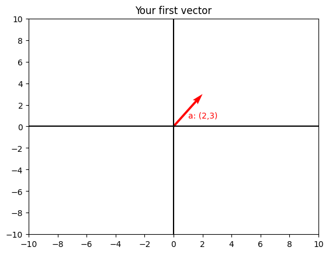

```python
### INTRO CODE###
import pandas as pd
import numpy as np
import matplotlib.pyplot as plt

#plt.rcParams['text.usetex'] = False

### BODY ###
#Initial 2-D Vector Graph
a = [2,3]

plt.hlines(0,-10,10,'black')
plt.vlines(0,-10,10,'black')
plt.xlim(-10,10)
plt.ylim(-10,10)
plt.xticks(np.arange(-10,12,2))
plt.yticks(np.arange(-10,12,2))
plt.quiver(0,0,a[0],a[1],color = 'red',scale = 1,
           scale_units = 'xy',angles = 'xy')
plt.text(1,.75,'a: (2,3)',color = 'red')
plt.title('Your first vector')
plt.show()
```

The above graph depicts **vector a**, pointing up and to the right. Note that the definition of a vector is just a magnitude and direction, so technically it didn't need to start at the origin point (0,0)

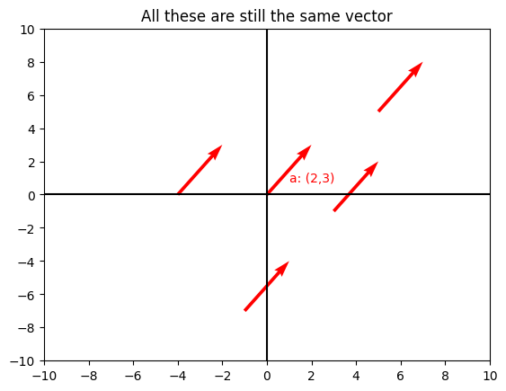

```python
plt.hlines(0,-10,10,'black')
plt.vlines(0,-10,10,'black')
plt.xlim(-10,10)
plt.ylim(-10,10)
plt.xticks(np.arange(-10,12,2))
plt.yticks(np.arange(-10,12,2))
plt.quiver(0,0,a[0],a[1],color = 'red',scale = 1,
           scale_units = 'xy',angles = 'xy')
plt.quiver(5,5,a[0],a[1],color = 'red',scale = 1,
           scale_units = 'xy',angles = 'xy')
plt.quiver(3,-1,a[0],a[1],color = 'red',scale = 1,
           scale_units = 'xy',angles = 'xy')
plt.quiver(-4,0,a[0],a[1],color = 'red',scale = 1,
           scale_units = 'xy',angles = 'xy')
plt.quiver(-1,-7,a[0],a[1],color = 'red',scale = 1,
           scale_units = 'xy',angles = 'xy')

plt.text(1,.75,'a: (2,3)',color = 'red')
plt.title('All these are still the same vector')
plt.show()
```

There are several ways to denote a vector.  
Component Notation: $\overrightarrow{a}$=$(2,3)$  
Matrix notation: $\overrightarrow{a}$ = $\left[\begin{array}{ccc} 2\\ 3 \end{array}\right]$  
Cartesian notation: $\overrightarrow{a}$=($\sqrt{13}, 56$°)

Another way is to define unit vectors (vectors with a length of one unit), then construct the vector out of said unit vectors:  
$\hat{i}=(1,0)$  
$\hat{j}=(0,1)$  
$\overrightarrow{a} = 2\hat{i}+3\hat{j}$

This brings us to an interesting observation. Notice that the unit vectors are multiplied by numbers. These numbers (2 and 3 in this case) are known as **scalars**. To multiply a vector by a scalar, simply multiply each component in the vector by the scalar:

$2\overrightarrow{a}= 2\cdot\left[\begin{array}{ccc} 2\\ 3 \end{array}\right]= \left[\begin{array}{ccc} 2\cdot2\\ 2\cdot3 \end{array}\right]= \left[\begin{array}{ccc} 4\\ 6 \end{array}\right]$

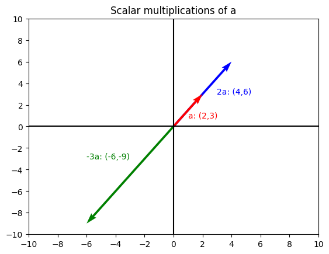

```python
### BODY ###
#Initial 2-D Vector Graph
a = [2,3]

plt.hlines(0,-10,10,'black')
plt.vlines(0,-10,10,'black')
plt.xlim(-10,10)
plt.ylim(-10,10)
plt.xticks(np.arange(-10,12,2))
plt.yticks(np.arange(-10,12,2))
plt.quiver(0,0,2*a[0],2*a[1],color = 'blue',scale = 1,
           scale_units = 'xy',angles = 'xy')
plt.quiver(0,0,a[0],a[1],color = 'red',scale = 1,
           scale_units = 'xy',angles = 'xy')
plt.quiver(0,0,-3*a[0],-3*a[1],color = 'green',scale = 1,
           scale_units = 'xy',angles = 'xy')
plt.text(3,3,'2a: (4,6)',color = 'blue')
plt.text(1,.75,'a: (2,3)',color = 'red')
plt.text(-6,-3,'-3a: (-6,-9)',color = 'green')
plt.title('Scalar multiplications of a')
plt.show()
```

You can also add vectors: $\overrightarrow{b}= \left[\begin{array}{ccc} 4\\ 1 \end{array}\right]\\ \overrightarrow{a}+\overrightarrow{b}= \left[\begin{array}{ccc} 2\\ 3 \end{array}\right]+ \left[\begin{array}{ccc} 4\\ 1 \end{array}\right]= \left[\begin{array}{ccc} 2+4\\ 3+1 \end{array}\right]= \left[\begin{array}{ccc} 6\\ 4 \end{array}\right]$

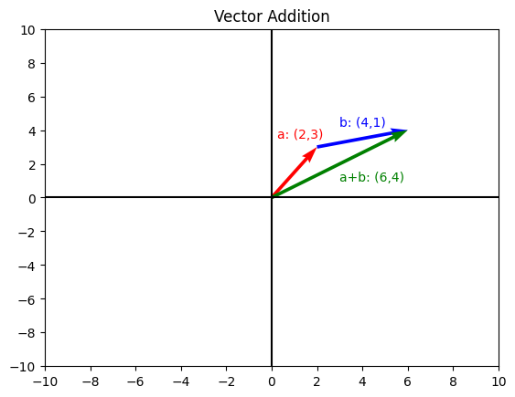

```python
### BODY ###
#Initial 2-D Vector Graph
a = [2,3]
b = [4,1]

plt.hlines(0,-10,10,'black')
plt.vlines(0,-10,10,'black')
plt.xlim(-10,10)
plt.ylim(-10,10)
plt.xticks(np.arange(-10,12,2))
plt.yticks(np.arange(-10,12,2))
plt.quiver(0,0,a[0],a[1],color = 'red',scale = 1,
           scale_units = 'xy',angles = 'xy')
plt.quiver(a[0],a[1],b[0],b[1],color = 'blue',scale = 1,
           scale_units = 'xy',angles = 'xy')
plt.quiver(0,0,a[0]+b[0],a[1]+b[1],color = 'green',scale = 1,
           scale_units = 'xy',angles = 'xy')
plt.text(3,4.25,'b: (4,1)',color = 'blue')
plt.text(0.25,3.5,'a: (2,3)',color = 'red')
plt.text(3,1,'a+b: (6,4)',color = 'green')

plt.title('Vector Addition')
plt.show()
```

This brings us to an interesting conclusion: you can produce any 2-dimensional vector from the linear combination of 2 vectors and their scalars, so long as they are linearly independent (not colinear or parallel). This can be expanded to any number of dimensions.  
$\begin{equation} Given\:V=\{v_1,v_2...v_n\}\:that\:are\:linearly\:independent,\exists C=\{c_1,c_2...c_n\}\in\mathbb{R}^n|\forall\overrightarrow{v}\in\mathbb{R}^n,\:\overrightarrow{v}=\sum_{i=1}^{n} {c_i v_i} \end{equation}$

Quick note: the set of all possible combinations resulting from a set of vectors is known as the **span** of said vectors.

This has been my brief blog on the basics of vectors, visualized with Python.